# phenology_results_v5

Pat Dumandan

I. Data Preparation

Notes:  
* use Sarah’s code to check for bad tags, bad periods and remove them  
* use only data from 1988-2014 (period when the plot assignments were fairly constant)  
* use only plot-level data from 18 plots (control and exclosure): 1, 2, 4, 8, 9, 11, 12, 14, 17, 22,3, 6, 13, 15, 18, 19, 20, 21  
* proportion of breeders is the number of individuals of a given species and sex in a given plot that exhibits reproductive characteristics divided by the total number of individuals of a given species and sex in a given plot  
* for months when no observations on reproductive individuals were made, set at 0 (not really account for detection bias)  
* lag of 1 set for NDVI and precipitation  
* all variables except month were standardized (centered each value on the mean and divide by two SDs, Gelman 2008)

**This is where I start to need Glenda’s input**  
* Am I applying the lags properly? If not, what’s the best way for me to do it?  
* Right now, I’m having problems with having Dec-Jan to transition properly. So I’m filling in the ndvi and precipitation with the value from the previous month, which I think isn’t necessarily correct, especially for precipitation. I think for NDVI it is acceptable? because of their high autocorrelation in values?  
* Is this something I could do using portalcasting functionalities?

```
##   year month precipitation       date      ndvi treatment reproductive
## 1 1988     1        22.352 1988-01-01 0.1352926   control            4
## 2 1988     1        22.352 1988-01-01 0.1352926 exclosure            0
## 3 1988     1        22.352 1988-01-01 0.1352926   control            0
## 4 1988     1        22.352 1988-01-01 0.1352926 exclosure            0
## 5 1988     2        33.274 1988-02-01 0.1166441   control            6
## 6 1988     2        33.274 1988-02-01 0.1166441 exclosure            2
##   abundance proportion    sex species bmass_DM bmass_DO bmass_DS bmass_PB
## 1        15  0.2666667   male      DM      927      509      435        0
## 2         6  0.0000000   male      DM      536      298        0        0
## 3         2  0.0000000 female      DM      927      509      435        0
## 4         7  0.0000000 female      DM      536      298        0        0
## 5        18  0.3333333   male      DM     1184      578      436        0
## 6         3  0.6666667   male      DM      220      251        0        0
##   bmass_PP DIPO_bmass  lag_ndvi lag_ppt month.y     years ndvis ppts dipos pbs
## 1        0       1871        NA      NA      NA -1.086131    NA   NA    NA  NA
## 2        0        834        NA      NA      NA -1.086131    NA   NA    NA  NA
## 3        0       1871        NA      NA      NA -1.086131    NA   NA    NA  NA
## 4        0        834        NA      NA      NA -1.086131    NA   NA    NA  NA
## 5        0       2198 0.1352926  22.352       1 -1.086131    NA   NA    NA  NA
## 6        0        471 0.1352926  22.352       1 -1.086131    NA   NA    NA  NA
##   pps
## 1  NA
## 2  NA
## 3  NA
## 4  NA
## 5  NA
## 6  NA
```

2. Analyses  
   *Goal*: Reconstruct breeding phenology of male and female PBs, PPs, and DMs in different biotic contexts (control vs k-rat exclosure) and determine the association between breeding odds and abiotic (i.e., NDVI, precipitation) and biotic (biomass of PB, PP, and all k-rats(DO,DM,DS)) factors.

*Models*:  
* build species- and sex- specific GAMs with increasing levels of complexity (Note: P(breeding)=proportion of individuals exhibiting reproductive characteristics)  
**M1 (abiotic only model)**: P(breeding)~ s(month)+ s(year)+ lag_ndvi + lag_precipitation  
**M2 (abiotic + intraspecific competition)**: P(breeding) ~ s(month)+ s(year)+ lag_ndvi + lag_precipitation + biomass of given population (e.g., if model for PBs, biomass of PBs)  
**M3 (abiotic + intra- and interspecific competition)**: P(breeding) ~ s(month)+ s(year)+ lag_ndvi + lag_precipitation + biomass of given population (e.g., if model for PBs, biomass of PBs) + biomass of other populations

*Modelling approaches*:  
**mod1**: GAM through mgcv package  
**mod2**: spline model with normal distribution in Stan  
**mod3**: spline model with beta-binomial distribution in Stan

A. Preliminary Analyses focused on building M1 through different modelling approaches  
*Notes*  
* dataset used is PB females in control  
* for now, building M1 through 3 different modelling approaches to see, which one is the most appropriate

First, visualize data so we have a point of reference (regression line is just proportion~month)

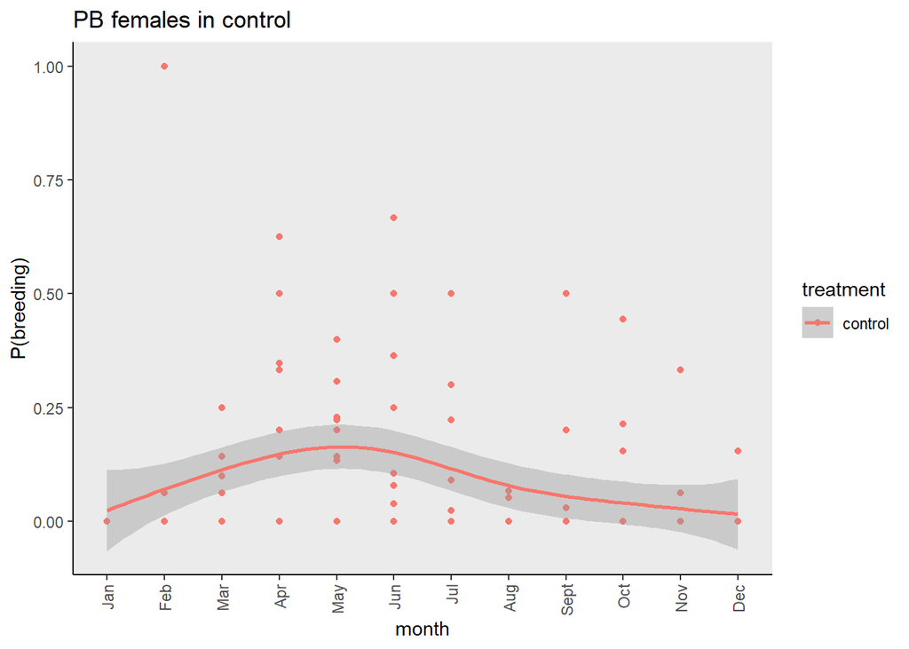

1. **M1 mod1**  
   This model draws from McLean and Guralnick’s paper (2020) where they built a separate GAM to reconstruct breeding phenology of PEMA and separate GLMMs to test for the relationship of breeding odds with breeding cues (i.e., photoperiod, temperature, precipitation). Not sure why they didn’t just make a single GAM and set the environmental variables as linear terms. Here we use a logistic function and cubic cyclic regression spline smoothers (bs=“cc” because breeding events are cyclical).

```r
#no explicit biotic effects
mod1=mgcv::gam(proportion~s(month, bs="cc")+s(year)+ lag_ndvi+lag_ppt, data=PB_female_con, method = 'REML', weights = abundance, family = binomial)
```

```
##
## Family: binomial
## Link function: logit
##
## Formula:
## proportion ~ s(month, bs = "cc") + s(year) + lag_ndvi + lag_ppt
##
## Parametric coefficients:
##              Estimate Std. Error z value Pr(>|z|)
## (Intercept) -4.243903   0.468236  -9.064  < 2e-16 ***
## lag_ndvi     8.244525   2.613593   3.154  0.00161 **
## lag_ppt     -0.002629   0.007881  -0.334  0.73864
## ---
## Signif. codes:  0 '***' 0.001 '**' 0.01 '*' 0.05 '.' 0.1 ' ' 1
##
## Approximate significance of smooth terms:
##            edf Ref.df Chi.sq p-value
## s(month) 4.505  8.000  80.95  <2e-16 ***
## s(year)  3.771  4.652  13.19  0.0172 *
## ---
## Signif. codes:  0 '***' 0.001 '**' 0.01 '*' 0.05 '.' 0.1 ' ' 1
##
## R-sq.(adj) =  0.423   Deviance explained =   48%
## -REML = 136.45  Scale est. = 1         n = 142
```

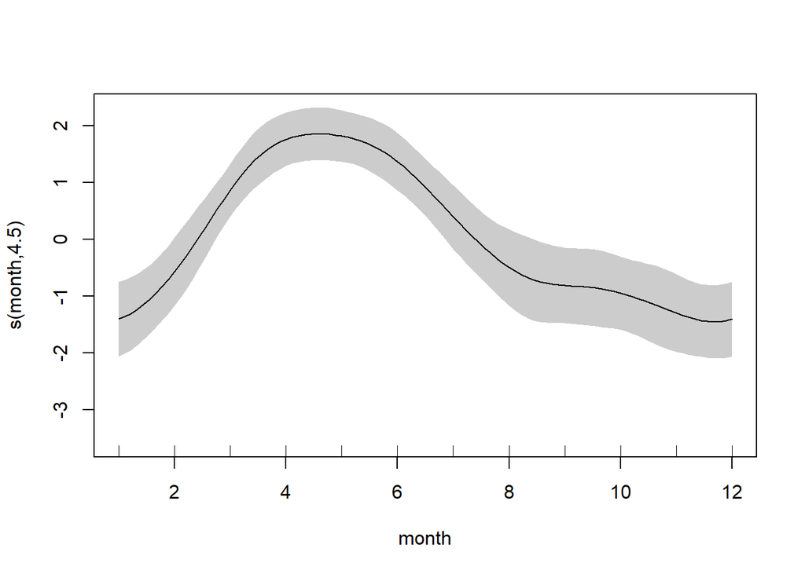

Fig.1. Partial effects plot (mod1)

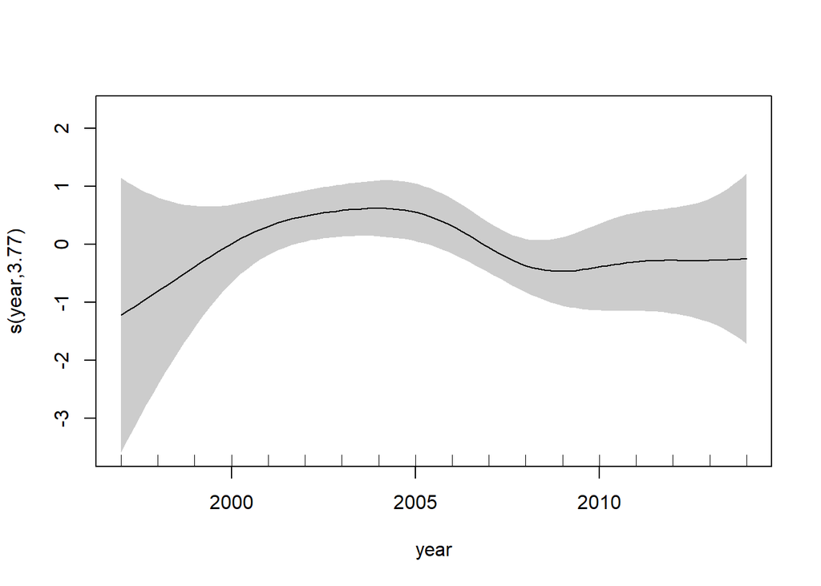

Fig.1. Partial effects plot (mod1)

```
## Inference for Stan model: 05d9ef8e4fdb8c6e3be41ba7a8f14fb2.
## 2 chains, each with iter=300; warmup=150; thin=1;
## post-warmup draws per chain=150, total post-warmup draws=300.
##
##           mean se_mean   sd  2.5%   25%   50%   75% 97.5% n_eff Rhat
## a0       -0.08    0.01 0.08 -0.24 -0.14 -0.08 -0.02  0.06    32 1.07
## ndvi_eff  0.41    0.01 0.24 -0.05  0.25  0.42  0.60  0.87   440 0.99
## ppt_eff   0.00    0.00 0.00  0.00  0.00  0.00  0.00  0.00   327 1.00
##
## Samples were drawn using NUTS(diag_e) at Fri May 21 10:29:25 2021.
## For each parameter, n_eff is a crude measure of effective sample size,
## and Rhat is the potential scale reduction factor on split chains (at
## convergence, Rhat=1).
```

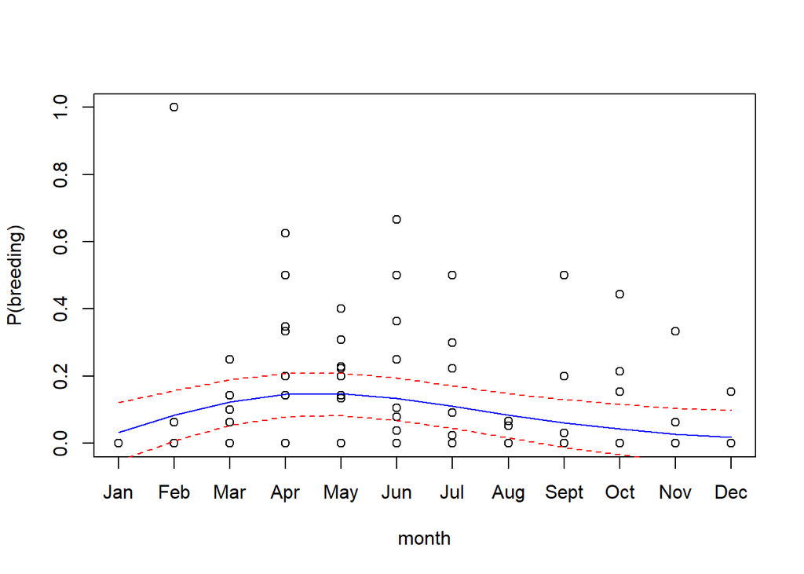

Fig.2a. spline fit over raw data (mod2)

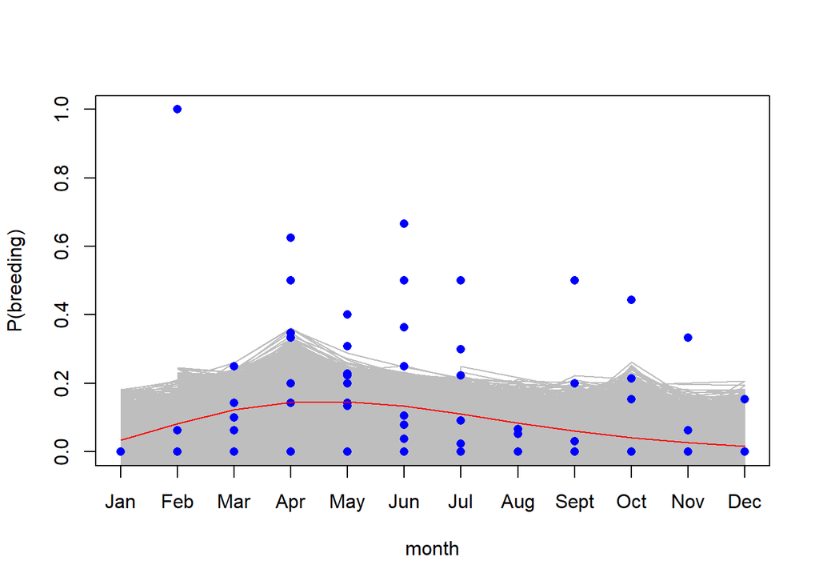

Fig.2b. posterior draws over raw data (mod2)

```r
X1 =PB_female_con$month
X2= PB_female_con$year
X3= PB_female_con$lag_ndvi
X4= PB_female_con$lag_ppt
num_data = length(X1)
B1 = t(bs(X1, df=NULL, knots=NULL, degree=3, intercept = FALSE)) # creating the B-splines, degree=3 for cubic spline
B2 = t(bs(X2, df=NULL, knots=NULL, degree=3, intercept = FALSE))
num_basis1 = nrow(B1)
num_basis2 = nrow(B2)
Y = PB_female_con$proportion

dat_list=list(X1 =PB_female_con$month,
              X2= PB_female_con$year,
              X3= PB_female_con$lag_ndvi,
              X4= PB_female_con$lag_ppt,
              num_data = length(X1),
              B1 = t(bs(X1, df=NULL, knots=NULL, degree=3, intercept = FALSE)), # creating the B-splines, degree=3 for cubic spline
              B2 = t(bs(X2, df=NULL, knots=NULL, degree=3, intercept = FALSE)),
              num_basis1 = nrow(B1),
              num_basis2 = nrow(B2),
              Y = PB_female_con$proportion)

mod2<-stan(model_code="
data {
  int num_data; //rows of observations
  int num_basis1; //no. of basis (order-1)
  int num_basis2; //no. of basis (order-1)
  real <lower=0,upper=1>Y[num_data]; //response variable (e.g., no.of breeding obs.)
  vector[num_data] X3; //lag_NDVI
  vector[num_data] X4; //lag_ppt
  matrix[num_basis1, num_data] B1; //matrix of coefficients of splines(rows), length of X1 (columns)
   matrix[num_basis2, num_data] B2; //matrix of coefficients of splines(rows), length of X1 (columns)
}

parameters {
  row_vector[num_basis1] a_raw; // smooth terms for month
  row_vector[num_basis2] b_raw; // smooth terms for year
  real a0; //intercept
  real ndvi_eff;
  real ppt_eff;

  real<lower=0> sigma; //error term for shape params
  real<lower=0> tau; // for noncentered parameterization of spline coefficients (month)
  real<lower=0> phi; // for noncentered parameterization of spline coefficients (year)

}

transformed parameters {
  row_vector[num_basis1] a; //noncentered parameters of splines
  row_vector[num_basis2] b; //noncentered parameters of splines

  vector[num_data] Y_hat;

  a = a_raw*tau;
  b = b_raw*phi;

 Y_hat=a0 + ndvi_eff*X3 +ppt_eff*X4 + to_vector(a*B1)+ to_vector(b*B2);
 }

model {
  a_raw ~ normal(0, 1);
  b_raw ~ normal(0, 1);
  phi~normal(0,1);
  tau ~ normal(0, 1);
  sigma ~ normal(0, 1);
  ndvi_eff~normal(0,1);
  ppt_eff~normal(0,1);

  Y~ normal(Y_hat, sigma);
  }",iter=300,
data =dat_list, chains=2)
```

3. **M1 mod3**  
   This model has added complexity by assuming a beta-binomial (BB) distribution. This may be appropriate because if we use a binomial distribution, the probabilities are fixed (proportions are fixed). But in BB models, probabilities changes from trial to trial. This will help us account for the variation in sample sizes. So, here, the proportion of breeding events (or probability of breeding/breeding odds) has a binomial distribution but this probability has a beta distribution with shape parameters.

```
## Inference for Stan model: a400a4add4ea4156026b1cc24132ba76.
## 4 chains, each with iter=200; warmup=100; thin=1;
## post-warmup draws per chain=100, total post-warmup draws=400.
##
##           mean se_mean   sd  2.5%   25%   50%   75% 97.5% n_eff Rhat
## a0       -3.18    0.11 0.62 -4.40 -3.61 -3.14 -2.74 -2.03    32 1.18
## ndvi_eff  0.35    0.06 0.89 -1.44 -0.25  0.38  0.99  2.06   227 1.01
## ppt_eff  -0.01    0.00 0.01 -0.03 -0.01 -0.01  0.00  0.01     4 1.64
##
## Samples were drawn using NUTS(diag_e) at Fri May 21 10:32:33 2021.
## For each parameter, n_eff is a crude measure of effective sample size,
## and Rhat is the potential scale reduction factor on split chains (at
## convergence, Rhat=1).
```

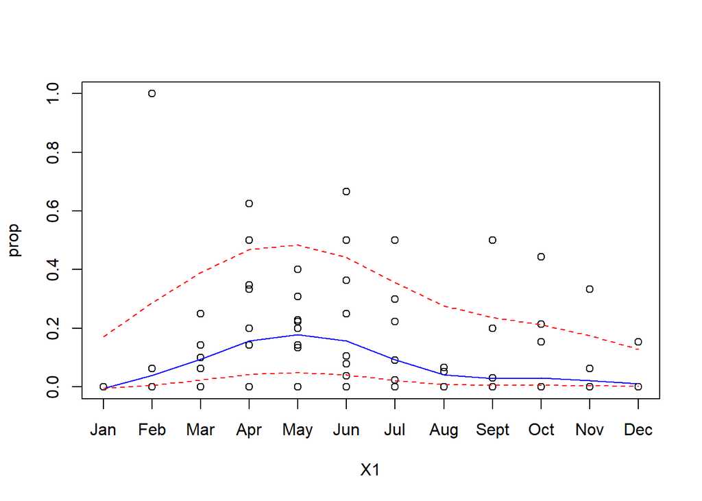

Fig.3a. spline fit over raw data (mod3)

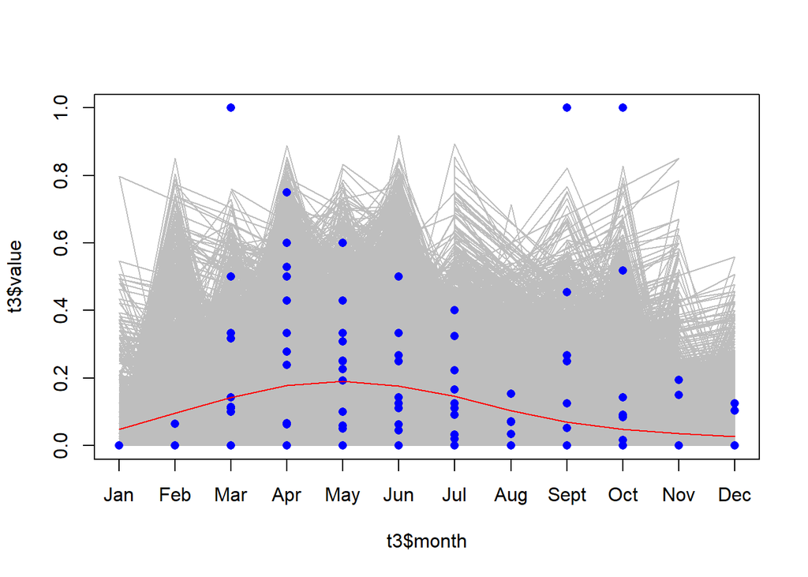

```r
X1 =PB_female_con$month
X2= PB_female_con$year
X3= PB_female_con$lag_ndvi
X4= PB_female_con$lag_ppt
num_data = length(X1)
B1 = t(bs(X1, df=NULL, knots=NULL, degree=3, intercept = FALSE)) # creating the B-splines, degree=3 for cubic spline
B2 = t(bs(X2, df=NULL, knots=NULL, degree=3, intercept = FALSE))
num_basis1 = nrow(B1)
num_basis2 = nrow(B2)
Y = PB_female_con$reproductive
n=PB_female_con$abundance

dat_list2=list(X1 =PB_female_con$month,
               X2= PB_female_con$year,
               X3= PB_female_con$lag_ndvi,
               X4= PB_female_con$lag_ppt,
               num_data = length(X1),
               B1 = t(bs(X1, df=NULL, knots=NULL, degree=3, intercept = FALSE)), # creating the B-splines, degree=3 for cubic spline
               B2 = t(bs(X2, df=NULL, knots=NULL, degree=3, intercept = FALSE)),
               num_basis1 = nrow(B1),
               num_basis2 = nrow(B2),
               Y = PB_female_con$reproductive,
               n=PB_female_con$abundance)

mod3<-stan(model_code="
data {
  int num_data; //rows of observations
  int num_basis1; //no. of basis (order-1)
  int num_basis2; //no. of basis (order-1)

  int Y[num_data]; //response variable (# of reproductive)
  int n[num_data]; //total no.of indivs in plot

  vector[num_data] X3; //lag_NDVI
  vector[num_data] X4; //lag_ppt

  matrix[num_basis1, num_data] B1; //matrix of coefficients of splines(rows), length of X1 (columns)
  matrix[num_basis2, num_data] B2; //matrix of coefficients of splines(rows), length of X1 (columns)

}

parameters {
 row_vector[num_basis1] a_raw; // smooth terms for month
  row_vector[num_basis2] b_raw; // smooth terms for year
  real a0; //intercept
  real ndvi_eff;
  real ppt_eff;

  real<lower=0> sigma; //error term for shape params
  real<lower=0> tau; // for noncentered parameterization of spline coefficients
  real<lower=0> phi; // for noncentered parameterization of spline coefficients (year)

 vector <lower=0, upper=1> [num_data] pred_repro;//breeding odds as a parameter
}

transformed parameters {
  row_vector[num_basis1] a; //noncentered parameters of splines
  row_vector[num_basis2] b; //noncentered parameters of splines

  //beta dist of probability as a deterministic function
  vector <lower=0, upper=1> [num_data] Y_hat; // mean of response variable

 //beta shape params
  vector <lower=0> [num_data] a1;
  vector <lower=0> [num_data] b1;

  a = a_raw*tau;
  b = b_raw*phi;

  Y_hat = inv_logit(a0 +ndvi_eff*X3+ ppt_eff*X4+ to_vector(a*B1)+ to_vector(b*B2));


a1=Y_hat*sigma;
b1=(1-Y_hat)*sigma;
}

model {
  a_raw ~ normal(0, 1);
  b_raw ~ normal(0, 1);
  tau ~ normal(0, 1);
  phi ~ normal(0, 1);
  sigma ~ normal(0, 1);
  ndvi_eff~normal(0,1);
  pred_repro ~ beta(a1, b1);
  Y~ binomial(n, pred_repro);
}",
         iter=200, control=list(max_treedepth=12),
         data =dat_list2)
```

**To figure out** * how to calculate derivatives from Stan output (in generated quantities block? maybe check Gavin’s gist for creating Deriv function?)  
* do I need to standardize the predictors for the smooth terms? or does it not matter, really? * how important is it to add a smoothing prior?  
* will I get the same results if I use a binomial distribution with a logit parameterization rather than a beta-binomial model?